# Project: Investigating TMBD dataset

- Introduction
- Data Wrangling
- Exploratory Data Analysis
- Conclusions

## Introduction

For this project, the TMBD dataset will be investigated. TMBD is a very famous website for movie revues and information, containing a multitude of data centered around the movies, who directed them, who starred in them, their genres, an overview of the movie, how much were these movies liked, how much they made, and how much was spent on them.

There are many questions that could be asked in this data-set and here are some examples I thought about

- Is budget related to revenue?
- Does employing multiple directors improve the quality of the movie?
- Which genres are more liked?
- Does the popularity of the imply a higher revenue?

The goal is to find answers to as many of these questions as possible. While The direct questions will be limited, their scope will try to encompass as much of these questions as possible

```python
# Use this cell to set up import statements for all of the packages that you
#   plan to use.

# Remember to include a 'magic word' so that your visualizations are plotted
#   inline with the notebook. See this page for more:
#   http://ipython.readthedocs.io/en/stable/interactive/magics.html

import pandas as pd
import matplotlib.pyplot as plt
import numpy as np
import seaborn as sns; sns.set()
import math
%matplotlib inline
```

## Data Wrangling

### General Properties

```python
# Load your data and print out a few lines. Perform operations to inspect data
#   types and look for instances of missing or possibly errant data.
movies = pd.read_csv("tmdb-movies.csv")
#appointment = pd.read_csv("noshow-appointments.csv")
```

```python
movies.info()
```

```
<class 'pandas.core.frame.DataFrame'>
RangeIndex: 10866 entries, 0 to 10865
Data columns (total 21 columns):
id                      10866 non-null int64
imdb_id                 10856 non-null object
popularity              10866 non-null float64
budget                  10866 non-null int64
revenue                 10866 non-null int64
original_title          10866 non-null object
cast                    10790 non-null object
homepage                2936 non-null object
director                10822 non-null object
tagline                 8042 non-null object
keywords                9373 non-null object
overview                10862 non-null object
runtime                 10866 non-null int64
genres                  10843 non-null object
production_companies    9836 non-null object
release_date            10866 non-null object
vote_count              10866 non-null int64
vote_average            10866 non-null float64
release_year            10866 non-null int64
budget_adj              10866 non-null float64
revenue_adj             10866 non-null float64
dtypes: float64(4), int64(6), object(11)
memory usage: 1.7+ MB
```

```python
movies.describe()
```

|  | id | popularity | budget | revenue | runtime | vote_count | vote_average | release_year | budget_adj | revenue_adj |
| --- | --- | --- | --- | --- | --- | --- | --- | --- | --- | --- |
| count | 10866.000000 | 10866.000000 | 1.086600e+04 | 1.086600e+04 | 10866.000000 | 10866.000000 | 10866.000000 | 10866.000000 | 1.086600e+04 | 1.086600e+04 |
| mean | 66064.177434 | 0.646441 | 1.462570e+07 | 3.982332e+07 | 102.070863 | 217.389748 | 5.974922 | 2001.322658 | 1.755104e+07 | 5.136436e+07 |
| std | 92130.136561 | 1.000185 | 3.091321e+07 | 1.170035e+08 | 31.381405 | 575.619058 | 0.935142 | 12.812941 | 3.430616e+07 | 1.446325e+08 |
| min | 5.000000 | 0.000065 | 0.000000e+00 | 0.000000e+00 | 0.000000 | 10.000000 | 1.500000 | 1960.000000 | 0.000000e+00 | 0.000000e+00 |
| 25% | 10596.250000 | 0.207583 | 0.000000e+00 | 0.000000e+00 | 90.000000 | 17.000000 | 5.400000 | 1995.000000 | 0.000000e+00 | 0.000000e+00 |
| 50% | 20669.000000 | 0.383856 | 0.000000e+00 | 0.000000e+00 | 99.000000 | 38.000000 | 6.000000 | 2006.000000 | 0.000000e+00 | 0.000000e+00 |
| 75% | 75610.000000 | 0.713817 | 1.500000e+07 | 2.400000e+07 | 111.000000 | 145.750000 | 6.600000 | 2011.000000 | 2.085325e+07 | 3.369710e+07 |
| max | 417859.000000 | 32.985763 | 4.250000e+08 | 2.781506e+09 | 900.000000 | 9767.000000 | 9.200000 | 2015.000000 | 4.250000e+08 | 2.827124e+09 |

```python
movies.head(10)
```

|  | id | imdb_id | popularity | budget | revenue | original_title | cast | homepage | director | tagline | ... | overview | runtime | genres | production_companies | release_date | vote_count | vote_average | release_year | budget_adj | revenue_adj |
| --- | --- | --- | --- | --- | --- | --- | --- | --- | --- | --- | --- | --- | --- | --- | --- | --- | --- | --- | --- | --- | --- |
| 0 | 135397 | tt0369610 | 32.985763 | 150000000 | 1513528810 | Jurassic World | Chris Pratt\|Bryce Dallas Howard\|Irrfan Khan\|Vi... | http://www.jurassicworld.com/ | Colin Trevorrow | The park is open. | ... | Twenty-two years after the events of Jurassic ... | 124 | Action\|Adventure\|Science Fiction\|Thriller | Universal Studios\|Amblin Entertainment\|Legenda... | 6/9/15 | 5562 | 6.5 | 2015 | 1.379999e+08 | 1.392446e+09 |
| 1 | 76341 | tt1392190 | 28.419936 | 150000000 | 378436354 | Mad Max: Fury Road | Tom Hardy\|Charlize Theron\|Hugh Keays-Byrne\|Nic... | http://www.madmaxmovie.com/ | George Miller | What a Lovely Day. | ... | An apocalyptic story set in the furthest reach... | 120 | Action\|Adventure\|Science Fiction\|Thriller | Village Roadshow Pictures\|Kennedy Miller Produ... | 5/13/15 | 6185 | 7.1 | 2015 | 1.379999e+08 | 3.481613e+08 |
| 2 | 262500 | tt2908446 | 13.112507 | 110000000 | 295238201 | Insurgent | Shailene Woodley\|Theo James\|Kate Winslet\|Ansel... | http://www.thedivergentseries.movie/#insurgent | Robert Schwentke | One Choice Can Destroy You | ... | Beatrice Prior must confront her inner demons ... | 119 | Adventure\|Science Fiction\|Thriller | Summit Entertainment\|Mandeville Films\|Red Wago... | 3/18/15 | 2480 | 6.3 | 2015 | 1.012000e+08 | 2.716190e+08 |
| 3 | 140607 | tt2488496 | 11.173104 | 200000000 | 2068178225 | Star Wars: The Force Awakens | Harrison Ford\|Mark Hamill\|Carrie Fisher\|Adam D... | http://www.starwars.com/films/star-wars-episod... | J.J. Abrams | Every generation has a story. | ... | Thirty years after defeating the Galactic Empi... | 136 | Action\|Adventure\|Science Fiction\|Fantasy | Lucasfilm\|Truenorth Productions\|Bad Robot | 12/15/15 | 5292 | 7.5 | 2015 | 1.839999e+08 | 1.902723e+09 |
| 4 | 168259 | tt2820852 | 9.335014 | 190000000 | 1506249360 | Furious 7 | Vin Diesel\|Paul Walker\|Jason Statham\|Michelle ... | http://www.furious7.com/ | James Wan | Vengeance Hits Home | ... | Deckard Shaw seeks revenge against Dominic Tor... | 137 | Action\|Crime\|Thriller | Universal Pictures\|Original Film\|Media Rights ... | 4/1/15 | 2947 | 7.3 | 2015 | 1.747999e+08 | 1.385749e+09 |
| 5 | 281957 | tt1663202 | 9.110700 | 135000000 | 532950503 | The Revenant | Leonardo DiCaprio\|Tom Hardy\|Will Poulter\|Domhn... | http://www.foxmovies.com/movies/the-revenant | Alejandro González Iñárritu | (n. One who has returned, as if from the dead.) | ... | In the 1820s, a frontiersman, Hugh Glass, sets... | 156 | Western\|Drama\|Adventure\|Thriller | Regency Enterprises\|Appian Way\|CatchPlay\|Anony... | 12/25/15 | 3929 | 7.2 | 2015 | 1.241999e+08 | 4.903142e+08 |
| 6 | 87101 | tt1340138 | 8.654359 | 155000000 | 440603537 | Terminator Genisys | Arnold Schwarzenegger\|Jason Clarke\|Emilia Clar... | http://www.terminatormovie.com/ | Alan Taylor | Reset the future | ... | The year is 2029. John Connor, leader of the r... | 125 | Science Fiction\|Action\|Thriller\|Adventure | Paramount Pictures\|Skydance Productions | 6/23/15 | 2598 | 5.8 | 2015 | 1.425999e+08 | 4.053551e+08 |
| 7 | 286217 | tt3659388 | 7.667400 | 108000000 | 595380321 | The Martian | Matt Damon\|Jessica Chastain\|Kristen Wiig\|Jeff ... | http://www.foxmovies.com/movies/the-martian | Ridley Scott | Bring Him Home | ... | During a manned mission to Mars, Astronaut Mar... | 141 | Drama\|Adventure\|Science Fiction | Twentieth Century Fox Film Corporation\|Scott F... | 9/30/15 | 4572 | 7.6 | 2015 | 9.935996e+07 | 5.477497e+08 |
| 8 | 211672 | tt2293640 | 7.404165 | 74000000 | 1156730962 | Minions | Sandra Bullock\|Jon Hamm\|Michael Keaton\|Allison... | http://www.minionsmovie.com/ | Kyle Balda\|Pierre Coffin | Before Gru, they had a history of bad bosses | ... | Minions Stuart, Kevin and Bob are recruited by... | 91 | Family\|Animation\|Adventure\|Comedy | Universal Pictures\|Illumination Entertainment | 6/17/15 | 2893 | 6.5 | 2015 | 6.807997e+07 | 1.064192e+09 |
| 9 | 150540 | tt2096673 | 6.326804 | 175000000 | 853708609 | Inside Out | Amy Poehler\|Phyllis Smith\|Richard Kind\|Bill Ha... | http://movies.disney.com/inside-out | Pete Docter | Meet the little voices inside your head. | ... | Growing up can be a bumpy road, and it's no ex... | 94 | Comedy\|Animation\|Family | Walt Disney Pictures\|Pixar Animation Studios\|W... | 6/9/15 | 3935 | 8.0 | 2015 | 1.609999e+08 | 7.854116e+08 |

10 rows × 21 columns

### Data Cleaning

#### The following list represents the steps I have taken in cleaning the data

1. Removed some irrelavent or too incomplete features like
   - Homepage
   - Overview
   - Production Companies
   - Keywords
   - tagline
   - Cast
2. removed duplicates
3. seperate genres into different columns, renaming them with genres, put them in lower case and remove spaces to make them easier to follow
4. Fill empty directors with NA
5. Redefine Directors into Solos (S) and Cooperates (C)
6. There were too many outliers with 0 budget or 0 revenue and many a little above it, it was decided that any reasonable budget or revenue would be above 10000, anything else is an outlier

**Now all the features have the same number of features, except genres that would be kept as a reference**

```python
# After discussing the structure of the data and any problems that need to be
#   cleaned, perform those cleaning steps in the second part of this section.
#movies = pd.read_csv("tmdb-movies.csv")
movies = movies.drop(columns=['homepage','overview','production_companies','tagline','keywords',"cast"])
movies = movies.drop_duplicates()
```

```python
genres = movies.genres.str.get_dummies()
genres = genres.rename(columns=lambda x: ((x+"_genre").replace(" ","_")).lower())
```

```python
movies = pd.concat([movies, genres], axis=1)
#movies = movies.append(cast) # Too much cast that my PC freezed while processing them
```

```python
movies.director.fillna("N", inplace=True)
```

```python
movies['director'] = np.where(movies['director'].str.find("|") != -1, "Cooporating", movies['director'])
movies['director'] = np.where(movies['director'] != "Cooporating" , "Solo", movies['director'])
```

```python
movies = movies[movies.revenue>10000]
movies = movies[movies.budget>10000]
```

```python
len(movies[movies['director'].str.find("|") != -1])
```

```
0
```

```python
movies.info()
```

```
<class 'pandas.core.frame.DataFrame'>
Int64Index: 3799 entries, 0 to 10848
Data columns (total 35 columns):
id                       3799 non-null int64
imdb_id                  3799 non-null object
popularity               3799 non-null float64
budget                   3799 non-null int64
revenue                  3799 non-null int64
original_title           3799 non-null object
director                 3799 non-null object
runtime                  3799 non-null int64
genres                   3799 non-null object
release_date             3799 non-null object
vote_count               3799 non-null int64
vote_average             3799 non-null float64
release_year             3799 non-null int64
budget_adj               3799 non-null float64
revenue_adj              3799 non-null float64
action_genre             3799 non-null int64
adventure_genre          3799 non-null int64
animation_genre          3799 non-null int64
comedy_genre             3799 non-null int64
crime_genre              3799 non-null int64
documentary_genre        3799 non-null int64
drama_genre              3799 non-null int64
family_genre             3799 non-null int64
fantasy_genre            3799 non-null int64
foreign_genre            3799 non-null int64
history_genre            3799 non-null int64
horror_genre             3799 non-null int64
music_genre              3799 non-null int64
mystery_genre            3799 non-null int64
romance_genre            3799 non-null int64
science_fiction_genre    3799 non-null int64
tv_movie_genre           3799 non-null int64
thriller_genre           3799 non-null int64
war_genre                3799 non-null int64
western_genre            3799 non-null int64
dtypes: float64(4), int64(26), object(5)
memory usage: 1.0+ MB
```

```python
popularity_outliers = movies.query("popularity>10")
unique_directors = movies.director.unique()
cooperating_directors = movies[movies['director'] == "Cooporating"]
solo_directors = movies[movies['director'] == "Solo"]
print("Number of probably outlier movies in popularity: "+ str(len(popularity_outliers)))
print("Number of unique directors: "+ str(len(unique_directors)))
print("Number of cooperating directors: "+ str(len(cooperating_directors)))
print("Number of single directors: "+ str(len(solo_directors)))
```

```
Number of probably outlier movies in popularity: 11
Number of unique directors: 2
Number of cooperating directors: 241
Number of single directors: 3558
```

```python
movies.describe()
```

|  | id | popularity | budget | revenue | runtime | vote_count | vote_average | release_year | budget_adj | revenue_adj | ... | history_genre | horror_genre | music_genre | mystery_genre | romance_genre | science_fiction_genre | tv_movie_genre | thriller_genre | war_genre | western_genre |
| --- | --- | --- | --- | --- | --- | --- | --- | --- | --- | --- | --- | --- | --- | --- | --- | --- | --- | --- | --- | --- | --- |
| count | 3799.000000 | 3799.000000 | 3.799000e+03 | 3.799000e+03 | 3799.000000 | 3799.000000 | 3799.00000 | 3799.000000 | 3.799000e+03 | 3.799000e+03 | ... | 3799.000000 | 3799.000000 | 3799.000000 | 3799.000000 | 3799.000000 | 3799.000000 | 3799.000000 | 3799.000000 | 3799.000000 | 3799.000000 |
| mean | 39684.873125 | 1.202152 | 3.763248e+07 | 1.092108e+08 | 109.385628 | 533.983153 | 6.17323 | 2001.238484 | 4.475220e+07 | 1.389776e+08 | ... | 0.033693 | 0.119242 | 0.035009 | 0.089760 | 0.171887 | 0.135036 | 0.000263 | 0.311924 | 0.031324 | 0.013425 |
| std | 67222.077680 | 1.482725 | 4.230551e+07 | 1.773449e+08 | 19.855137 | 884.598454 | 0.79204 | 11.299503 | 4.485738e+07 | 2.170490e+08 | ... | 0.180462 | 0.324116 | 0.183827 | 0.285876 | 0.377332 | 0.341807 | 0.016224 | 0.463340 | 0.174215 | 0.115099 |
| min | 5.000000 | 0.001117 | 1.200000e+04 | 1.028900e+04 | 26.000000 | 10.000000 | 2.20000 | 1960.000000 | 1.577503e+04 | 1.148832e+04 | ... | 0.000000 | 0.000000 | 0.000000 | 0.000000 | 0.000000 | 0.000000 | 0.000000 | 0.000000 | 0.000000 | 0.000000 |
| 25% | 5980.000000 | 0.467321 | 1.000000e+07 | 1.452172e+07 | 96.000000 | 73.000000 | 5.70000 | 1995.000000 | 1.355211e+07 | 1.950884e+07 | ... | 0.000000 | 0.000000 | 0.000000 | 0.000000 | 0.000000 | 0.000000 | 0.000000 | 0.000000 | 0.000000 | 0.000000 |
| 50% | 11282.000000 | 0.808336 | 2.500000e+07 | 4.624300e+07 | 106.000000 | 207.000000 | 6.20000 | 2004.000000 | 3.038360e+07 | 6.314477e+07 | ... | 0.000000 | 0.000000 | 0.000000 | 0.000000 | 0.000000 | 0.000000 | 0.000000 | 0.000000 | 0.000000 | 0.000000 |
| 75% | 38339.000000 | 1.387598 | 5.000000e+07 | 1.262329e+08 | 119.000000 | 584.000000 | 6.70000 | 2010.000000 | 6.082825e+07 | 1.658094e+08 | ... | 0.000000 | 0.000000 | 0.000000 | 0.000000 | 0.000000 | 0.000000 | 0.000000 | 1.000000 | 0.000000 | 0.000000 |
| max | 417859.000000 | 32.985763 | 4.250000e+08 | 2.781506e+09 | 338.000000 | 9767.000000 | 8.40000 | 2015.000000 | 4.250000e+08 | 2.827124e+09 | ... | 1.000000 | 1.000000 | 1.000000 | 1.000000 | 1.000000 | 1.000000 | 1.000000 | 1.000000 | 1.000000 | 1.000000 |

8 rows × 30 columns

```python
#print(movies.cast[9])
```

## Exploratory Data Analysis

### Research Question 1: How different are cooperating directors compared to solo directors?

```python
# Use this, and more code cells, to explore your data. Don't forget to add
#   Markdown cells to document your observations and findings.

cooperating_directors = movies[movies['director'] == "Cooporating"]
solo_directors = movies[movies['director'] == "Solo"]
```

```python
cooperating_directors.describe()
```

|  | id | popularity | budget | revenue | runtime | vote_count | vote_average | release_year | budget_adj | revenue_adj | ... | history_genre | horror_genre | music_genre | mystery_genre | romance_genre | science_fiction_genre | tv_movie_genre | thriller_genre | war_genre | western_genre |
| --- | --- | --- | --- | --- | --- | --- | --- | --- | --- | --- | --- | --- | --- | --- | --- | --- | --- | --- | --- | --- | --- |
| count | 241.000000 | 241.000000 | 2.410000e+02 | 2.410000e+02 | 241.000000 | 241.000000 | 241.000000 | 241.000000 | 2.410000e+02 | 2.410000e+02 | ... | 241.000000 | 241.000000 | 241.000000 | 241.000000 | 241.000000 | 241.000000 | 241.0 | 241.000000 | 241.000000 | 241.000000 |
| mean | 43223.211618 | 1.570817 | 4.784032e+07 | 1.641238e+08 | 98.821577 | 759.136929 | 6.202905 | 2003.240664 | 5.592936e+07 | 1.957120e+08 | ... | 0.012448 | 0.091286 | 0.041494 | 0.016598 | 0.107884 | 0.132780 | 0.0 | 0.165975 | 0.012448 | 0.016598 |
| std | 65645.315868 | 1.700714 | 4.968264e+07 | 2.283309e+08 | 19.248087 | 1006.820305 | 0.855297 | 11.264998 | 5.376321e+07 | 2.605846e+08 | ... | 0.111105 | 0.288615 | 0.199844 | 0.128024 | 0.310879 | 0.340043 | 0.0 | 0.372833 | 0.111105 | 0.128024 |
| min | 5.000000 | 0.001117 | 2.500000e+04 | 7.136800e+04 | 63.000000 | 10.000000 | 3.300000 | 1961.000000 | 3.000000e+04 | 6.921354e+04 | ... | 0.000000 | 0.000000 | 0.000000 | 0.000000 | 0.000000 | 0.000000 | 0.0 | 0.000000 | 0.000000 | 0.000000 |
| 25% | 9023.000000 | 0.551406 | 1.000000e+07 | 1.670286e+07 | 89.000000 | 112.000000 | 5.800000 | 1999.000000 | 1.298003e+07 | 2.171471e+07 | ... | 0.000000 | 0.000000 | 0.000000 | 0.000000 | 0.000000 | 0.000000 | 0.0 | 0.000000 | 0.000000 | 0.000000 |
| 50% | 12572.000000 | 1.037708 | 2.800000e+07 | 6.682104e+07 | 95.000000 | 354.000000 | 6.300000 | 2007.000000 | 3.753585e+07 | 9.181743e+07 | ... | 0.000000 | 0.000000 | 0.000000 | 0.000000 | 0.000000 | 0.000000 | 0.0 | 0.000000 | 0.000000 | 0.000000 |
| 75% | 50646.000000 | 1.929641 | 7.500000e+07 | 2.015853e+08 | 104.000000 | 980.000000 | 6.800000 | 2011.000000 | 8.413349e+07 | 2.562191e+08 | ... | 0.000000 | 0.000000 | 0.000000 | 0.000000 | 0.000000 | 0.000000 | 0.0 | 0.000000 | 0.000000 | 0.000000 |
| max | 308638.000000 | 12.971027 | 2.600000e+08 | 1.274219e+09 | 248.000000 | 6351.000000 | 7.800000 | 2015.000000 | 2.600000e+08 | 1.574815e+09 | ... | 1.000000 | 1.000000 | 1.000000 | 1.000000 | 1.000000 | 1.000000 | 0.0 | 1.000000 | 1.000000 | 1.000000 |

8 rows × 30 columns

```python
solo_directors.describe()
```

|  | id | popularity | budget | revenue | runtime | vote_count | vote_average | release_year | budget_adj | revenue_adj | ... | history_genre | horror_genre | music_genre | mystery_genre | romance_genre | science_fiction_genre | tv_movie_genre | thriller_genre | war_genre | western_genre |
| --- | --- | --- | --- | --- | --- | --- | --- | --- | --- | --- | --- | --- | --- | --- | --- | --- | --- | --- | --- | --- | --- |
| count | 3558.000000 | 3558.000000 | 3.558000e+03 | 3.558000e+03 | 3558.000000 | 3558.000000 | 3558.00000 | 3558.000000 | 3.558000e+03 | 3.558000e+03 | ... | 3558.000000 | 3558.000000 | 3558.000000 | 3558.000000 | 3558.000000 | 3558.000000 | 3558.000000 | 3558.000000 | 3558.000000 | 3558.000000 |
| mean | 39445.204890 | 1.177180 | 3.694105e+07 | 1.054913e+08 | 110.101180 | 518.732434 | 6.17122 | 2001.102867 | 4.399511e+07 | 1.351348e+08 | ... | 0.035132 | 0.121135 | 0.034570 | 0.094716 | 0.176223 | 0.135188 | 0.000281 | 0.321810 | 0.032603 | 0.013210 |
| std | 67329.844248 | 1.463707 | 4.167654e+07 | 1.727608e+08 | 19.694301 | 873.767260 | 0.78766 | 11.290580 | 4.409594e+07 | 2.132783e+08 | ... | 0.184140 | 0.326331 | 0.182714 | 0.292864 | 0.381063 | 0.341973 | 0.016765 | 0.467236 | 0.177619 | 0.114188 |
| min | 11.000000 | 0.010335 | 1.200000e+04 | 1.028900e+04 | 26.000000 | 10.000000 | 2.20000 | 1960.000000 | 1.577503e+04 | 1.148832e+04 | ... | 0.000000 | 0.000000 | 0.000000 | 0.000000 | 0.000000 | 0.000000 | 0.000000 | 0.000000 | 0.000000 | 0.000000 |
| 25% | 5737.250000 | 0.464331 | 1.000000e+07 | 1.440473e+07 | 96.000000 | 71.000000 | 5.70000 | 1995.000000 | 1.357645e+07 | 1.945871e+07 | ... | 0.000000 | 0.000000 | 0.000000 | 0.000000 | 0.000000 | 0.000000 | 0.000000 | 0.000000 | 0.000000 | 0.000000 |
| 50% | 11214.500000 | 0.794616 | 2.400000e+07 | 4.559545e+07 | 106.000000 | 204.000000 | 6.20000 | 2004.000000 | 3.030653e+07 | 6.217234e+07 | ... | 0.000000 | 0.000000 | 0.000000 | 0.000000 | 0.000000 | 0.000000 | 0.000000 | 0.000000 | 0.000000 | 0.000000 |
| 75% | 37773.250000 | 1.352296 | 5.000000e+07 | 1.222255e+08 | 120.000000 | 563.000000 | 6.70000 | 2010.000000 | 5.985318e+07 | 1.608272e+08 | ... | 0.000000 | 0.000000 | 0.000000 | 0.000000 | 0.000000 | 0.000000 | 0.000000 | 1.000000 | 0.000000 | 0.000000 |
| max | 417859.000000 | 32.985763 | 4.250000e+08 | 2.781506e+09 | 338.000000 | 9767.000000 | 8.40000 | 2015.000000 | 4.250000e+08 | 2.827124e+09 | ... | 1.000000 | 1.000000 | 1.000000 | 1.000000 | 1.000000 | 1.000000 | 1.000000 | 1.000000 | 1.000000 | 1.000000 |

8 rows × 30 columns

```python
solo_directors_deducted = solo_directors[cooperating_directors.revenue.min() < solo_directors.revenue]
```

```python
solo_directors_deducted = solo_directors_deducted[solo_directors_deducted.popularity > cooperating_directors.popularity.min()]
```

```python
solo_directors_deducted.describe()
```

|  | id | popularity | budget | revenue | runtime | vote_count | vote_average | release_year | budget_adj | revenue_adj | ... | history_genre | horror_genre | music_genre | mystery_genre | romance_genre | science_fiction_genre | tv_movie_genre | thriller_genre | war_genre | western_genre |
| --- | --- | --- | --- | --- | --- | --- | --- | --- | --- | --- | --- | --- | --- | --- | --- | --- | --- | --- | --- | --- | --- |
| count | 3520.000000 | 3520.000000 | 3.520000e+03 | 3.520000e+03 | 3520.000000 | 3520.000000 | 3520.000000 | 3520.000000 | 3.520000e+03 | 3.520000e+03 | ... | 3520.000000 | 3520.000000 | 3520.000000 | 3520.000000 | 3520.000000 | 3520.000000 | 3520.000000 | 3520.000000 | 3520.000000 | 3520.000000 |
| mean | 38964.261932 | 1.184695 | 3.726799e+07 | 1.066297e+08 | 110.203977 | 523.448295 | 6.176307 | 2001.016477 | 4.439592e+07 | 1.365932e+08 | ... | 0.035511 | 0.121023 | 0.034375 | 0.094886 | 0.176705 | 0.135511 | 0.000284 | 0.321023 | 0.032386 | 0.013352 |
| std | 66921.493662 | 1.469507 | 4.177827e+07 | 1.733414e+08 | 19.727265 | 877.218138 | 0.786853 | 11.304927 | 4.416015e+07 | 2.139618e+08 | ... | 0.185095 | 0.326200 | 0.182216 | 0.293100 | 0.381473 | 0.342318 | 0.016855 | 0.466936 | 0.177049 | 0.114794 |
| min | 11.000000 | 0.010335 | 1.200000e+04 | 7.370600e+04 | 26.000000 | 10.000000 | 2.200000 | 1960.000000 | 1.577503e+04 | 7.000185e+04 | ... | 0.000000 | 0.000000 | 0.000000 | 0.000000 | 0.000000 | 0.000000 | 0.000000 | 0.000000 | 0.000000 | 0.000000 |
| 25% | 5548.750000 | 0.468108 | 1.000000e+07 | 1.497485e+07 | 97.000000 | 73.000000 | 5.700000 | 1995.000000 | 1.385334e+07 | 2.036753e+07 | ... | 0.000000 | 0.000000 | 0.000000 | 0.000000 | 0.000000 | 0.000000 | 0.000000 | 0.000000 | 0.000000 | 0.000000 |
| 50% | 11131.000000 | 0.801529 | 2.500000e+07 | 4.645678e+07 | 106.000000 | 207.000000 | 6.200000 | 2004.000000 | 3.041413e+07 | 6.334445e+07 | ... | 0.000000 | 0.000000 | 0.000000 | 0.000000 | 0.000000 | 0.000000 | 0.000000 | 0.000000 | 0.000000 | 0.000000 |
| 75% | 37144.000000 | 1.357177 | 5.000000e+07 | 1.233270e+08 | 120.000000 | 569.000000 | 6.700000 | 2010.000000 | 6.019874e+07 | 1.625865e+08 | ... | 0.000000 | 0.000000 | 0.000000 | 0.000000 | 0.000000 | 0.000000 | 0.000000 | 1.000000 | 0.000000 | 0.000000 |
| max | 417859.000000 | 32.985763 | 4.250000e+08 | 2.781506e+09 | 338.000000 | 9767.000000 | 8.400000 | 2015.000000 | 4.250000e+08 | 2.827124e+09 | ... | 1.000000 | 1.000000 | 1.000000 | 1.000000 | 1.000000 | 1.000000 | 1.000000 | 1.000000 | 1.000000 | 1.000000 |

8 rows × 30 columns

```python
cooperating_directors.describe()
```

|  | id | popularity | budget | revenue | runtime | vote_count | vote_average | release_year | budget_adj | revenue_adj | ... | history_genre | horror_genre | music_genre | mystery_genre | romance_genre | science_fiction_genre | tv_movie_genre | thriller_genre | war_genre | western_genre |
| --- | --- | --- | --- | --- | --- | --- | --- | --- | --- | --- | --- | --- | --- | --- | --- | --- | --- | --- | --- | --- | --- |
| count | 241.000000 | 241.000000 | 2.410000e+02 | 2.410000e+02 | 241.000000 | 241.000000 | 241.000000 | 241.000000 | 2.410000e+02 | 2.410000e+02 | ... | 241.000000 | 241.000000 | 241.000000 | 241.000000 | 241.000000 | 241.000000 | 241.0 | 241.000000 | 241.000000 | 241.000000 |
| mean | 43223.211618 | 1.570817 | 4.784032e+07 | 1.641238e+08 | 98.821577 | 759.136929 | 6.202905 | 2003.240664 | 5.592936e+07 | 1.957120e+08 | ... | 0.012448 | 0.091286 | 0.041494 | 0.016598 | 0.107884 | 0.132780 | 0.0 | 0.165975 | 0.012448 | 0.016598 |
| std | 65645.315868 | 1.700714 | 4.968264e+07 | 2.283309e+08 | 19.248087 | 1006.820305 | 0.855297 | 11.264998 | 5.376321e+07 | 2.605846e+08 | ... | 0.111105 | 0.288615 | 0.199844 | 0.128024 | 0.310879 | 0.340043 | 0.0 | 0.372833 | 0.111105 | 0.128024 |
| min | 5.000000 | 0.001117 | 2.500000e+04 | 7.136800e+04 | 63.000000 | 10.000000 | 3.300000 | 1961.000000 | 3.000000e+04 | 6.921354e+04 | ... | 0.000000 | 0.000000 | 0.000000 | 0.000000 | 0.000000 | 0.000000 | 0.0 | 0.000000 | 0.000000 | 0.000000 |
| 25% | 9023.000000 | 0.551406 | 1.000000e+07 | 1.670286e+07 | 89.000000 | 112.000000 | 5.800000 | 1999.000000 | 1.298003e+07 | 2.171471e+07 | ... | 0.000000 | 0.000000 | 0.000000 | 0.000000 | 0.000000 | 0.000000 | 0.0 | 0.000000 | 0.000000 | 0.000000 |
| 50% | 12572.000000 | 1.037708 | 2.800000e+07 | 6.682104e+07 | 95.000000 | 354.000000 | 6.300000 | 2007.000000 | 3.753585e+07 | 9.181743e+07 | ... | 0.000000 | 0.000000 | 0.000000 | 0.000000 | 0.000000 | 0.000000 | 0.0 | 0.000000 | 0.000000 | 0.000000 |
| 75% | 50646.000000 | 1.929641 | 7.500000e+07 | 2.015853e+08 | 104.000000 | 980.000000 | 6.800000 | 2011.000000 | 8.413349e+07 | 2.562191e+08 | ... | 0.000000 | 0.000000 | 0.000000 | 0.000000 | 0.000000 | 0.000000 | 0.0 | 0.000000 | 0.000000 | 0.000000 |
| max | 308638.000000 | 12.971027 | 2.600000e+08 | 1.274219e+09 | 248.000000 | 6351.000000 | 7.800000 | 2015.000000 | 2.600000e+08 | 1.574815e+09 | ... | 1.000000 | 1.000000 | 1.000000 | 1.000000 | 1.000000 | 1.000000 | 0.0 | 1.000000 | 1.000000 | 1.000000 |

8 rows × 30 columns

### Early observation

Popularity wise, all the solo director's movies were of the outlier, so this early basic observation from the above cells will ignored.

For Revenue wise however, the solo movies seem to be having far more earning, as Avatar is almost twice as much revenue as Frozen

```python
combined_data =  pd.concat([solo_directors_deducted,cooperating_directors])
```

```python
solo_directors_deducted.info()
```

```
<class 'pandas.core.frame.DataFrame'>
Int64Index: 3520 entries, 0 to 10848
Data columns (total 35 columns):
id                       3520 non-null int64
imdb_id                  3520 non-null object
popularity               3520 non-null float64
budget                   3520 non-null int64
revenue                  3520 non-null int64
original_title           3520 non-null object
director                 3520 non-null object
runtime                  3520 non-null int64
genres                   3520 non-null object
release_date             3520 non-null object
vote_count               3520 non-null int64
vote_average             3520 non-null float64
release_year             3520 non-null int64
budget_adj               3520 non-null float64
revenue_adj              3520 non-null float64
action_genre             3520 non-null int64
adventure_genre          3520 non-null int64
animation_genre          3520 non-null int64
comedy_genre             3520 non-null int64
crime_genre              3520 non-null int64
documentary_genre        3520 non-null int64
drama_genre              3520 non-null int64
family_genre             3520 non-null int64
fantasy_genre            3520 non-null int64
foreign_genre            3520 non-null int64
history_genre            3520 non-null int64
horror_genre             3520 non-null int64
music_genre              3520 non-null int64
mystery_genre            3520 non-null int64
romance_genre            3520 non-null int64
science_fiction_genre    3520 non-null int64
tv_movie_genre           3520 non-null int64
thriller_genre           3520 non-null int64
war_genre                3520 non-null int64
western_genre            3520 non-null int64
dtypes: float64(4), int64(26), object(5)
memory usage: 990.0+ KB
```

**Generally in the plots below, the solo directors seem to generally prefer having "more".**

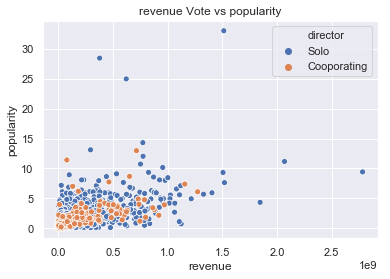

```python
ax = sns.scatterplot(x="revenue", y="popularity",hue="director", data=combined_data).set_title('revenue Vote vs popularity')
```

Most average solo directors have more freedom in their runtime, which is why many average solo movies have a longer runtime, there however seems to be no definite correlation between revenue and runtime.

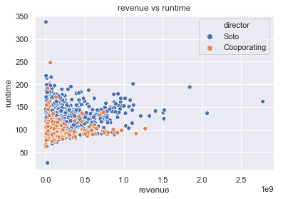

```python
ax = sns.scatterplot(x="revenue", y="runtime",hue="director", data=combined_data).set_title('revenue vs runtime')
```

This plot does not add anything new to what was previously mentioned

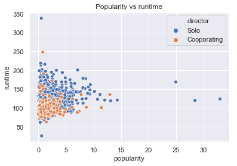

```python
ax = sns.scatterplot(x="popularity", y="runtime",hue="director", data=combined_data).set_title('Popularity vs runtime')
```

This does show that more solo movies get votes compared to cooporations, however no correlation here

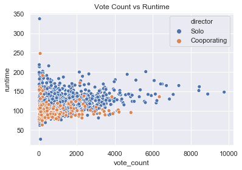

```python
ax = sns.scatterplot(x="vote_count", y="runtime",hue="director", data=combined_data).set_title('Vote Count vs Runtime')
```

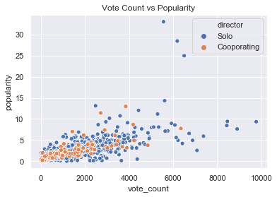

```python
ax = sns.scatterplot(x="vote_count", y="popularity",hue="director", data=combined_data).set_title('Vote Count vs Popularity')
```

This one furthermore confirms it, as apparently, if more people watch a movie and pay the ticket, they will also likely vote for it.

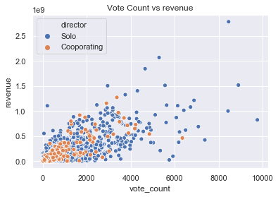

```python
ax = sns.scatterplot(x="vote_count", y="revenue",hue="director", data=combined_data).set_title('Vote Count vs revenue')
```

These last two plots are the most important, as together they reveal several information:

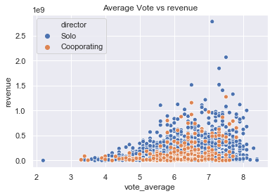

```python
ax = sns.scatterplot(x="vote_average", y="revenue",hue="director", data=combined_data).set_title('Average Vote vs revenue')
```

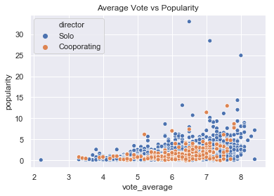

```python
ax = sns.scatterplot(x="vote_average", y="popularity",hue="director", data=combined_data).set_title('Average Vote vs Popularity')
```

**In order to get a final view on the directors earning and popularity, a boxplot chart will show the distribution of earning and popularity**

As we can see in the last two charts, the cooporating directors have more of their population inside the upper quartile than does the solo directors, that would indicate that cooporating directors may have a more consistent profit and popularity compared to solos, howeve this observation can be mostly attributed to the small number of those movies compared to solos

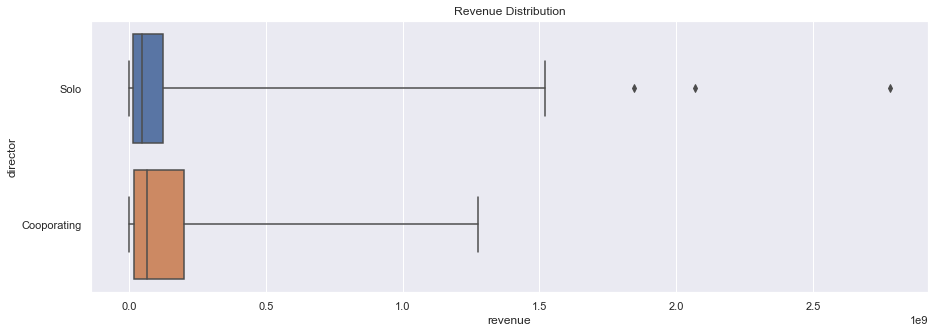

```python
plt.figure(figsize=(15,5))
ax = sns.boxplot(y="director", x="revenue", data=combined_data,whis=15).set_title('Revenue Distribution')
```

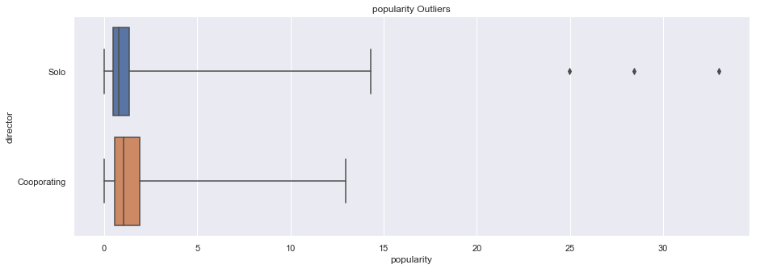

```python
plt.figure(figsize=(15,5))
ax = sns.boxplot(y="director", x="popularity", data=combined_data,whis=15).set_title('popularity Outliers')
```

### Research Question 2: Is genre related to popularity?

Multiple movies from different genres were made over the years, some were movies had several genres built into them, but which genres were conistently the more successful over the years? Also does popularity improve the revenue or not?

### The below charts are mostly incomprehensible since most genres overlap, we would need other charts

It is meant to show how much the movie changed popularity and revenue have change over the years, however all genres overlap and there are many movies, we could seperate them and analyse them individually. This may not be helpful either, we could try to remove all the lesser movies that earned too little to be considered influential, as many genres have their share of botched movies.

Popularity under 1 will be removed thereafter

**The following cells seperate all the genres into different part of the dictionary so they could be processed separetly**

```python
genres.columns
```

```
Index(['action_genre', 'adventure_genre', 'animation_genre', 'comedy_genre',
       'crime_genre', 'documentary_genre', 'drama_genre', 'family_genre',
       'fantasy_genre', 'foreign_genre', 'history_genre', 'horror_genre',
       'music_genre', 'mystery_genre', 'romance_genre',
       'science_fiction_genre', 'tv_movie_genre', 'thriller_genre',
       'war_genre', 'western_genre'],
      dtype='object')
```

```python
reducedMovies = movies[movies.popularity>1]
#reducedMovies = reducedMovies[reducedMovies.revenue>1000000]
reducedMovies.describe()
```

|  | id | popularity | budget | revenue | runtime | vote_count | vote_average | release_year | budget_adj | revenue_adj | ... | history_genre | horror_genre | music_genre | mystery_genre | romance_genre | science_fiction_genre | tv_movie_genre | thriller_genre | war_genre | western_genre |
| --- | --- | --- | --- | --- | --- | --- | --- | --- | --- | --- | --- | --- | --- | --- | --- | --- | --- | --- | --- | --- | --- |
| count | 1521.000000 | 1521.000000 | 1.521000e+03 | 1.521000e+03 | 1521.000000 | 1521.000000 | 1521.000000 | 1521.000000 | 1.521000e+03 | 1.521000e+03 | ... | 1521.000000 | 1521.000000 | 1521.000000 | 1521.000000 | 1521.000000 | 1521.000000 | 1521.0 | 1521.000000 | 1521.000000 | 1521.000000 |
| mean | 51338.631821 | 2.199479 | 5.804737e+07 | 2.058130e+08 | 112.767258 | 1091.024984 | 6.440500 | 2003.558843 | 6.537600e+07 | 2.519608e+08 | ... | 0.026298 | 0.086128 | 0.024984 | 0.089415 | 0.151216 | 0.182117 | 0.0 | 0.320842 | 0.034845 | 0.011177 |
| std | 80768.396171 | 1.934869 | 5.284204e+07 | 2.362237e+08 | 20.472568 | 1155.299761 | 0.754872 | 10.890876 | 5.411703e+07 | 2.875155e+08 | ... | 0.160074 | 0.280645 | 0.156126 | 0.285435 | 0.358377 | 0.386068 | 0.0 | 0.466954 | 0.183449 | 0.105163 |
| min | 5.000000 | 1.000194 | 1.500000e+04 | 5.013600e+04 | 63.000000 | 10.000000 | 3.700000 | 1960.000000 | 1.577503e+04 | 4.612510e+04 | ... | 0.000000 | 0.000000 | 0.000000 | 0.000000 | 0.000000 | 0.000000 | 0.0 | 0.000000 | 0.000000 | 0.000000 |
| 25% | 1738.000000 | 1.231168 | 2.000000e+07 | 5.941861e+07 | 98.000000 | 377.000000 | 5.900000 | 1999.000000 | 2.607776e+07 | 7.252661e+07 | ... | 0.000000 | 0.000000 | 0.000000 | 0.000000 | 0.000000 | 0.000000 | 0.0 | 0.000000 | 0.000000 | 0.000000 |
| 50% | 10112.000000 | 1.616724 | 4.000000e+07 | 1.314262e+08 | 109.000000 | 702.000000 | 6.400000 | 2007.000000 | 4.846990e+07 | 1.608228e+08 | ... | 0.000000 | 0.000000 | 0.000000 | 0.000000 | 0.000000 | 0.000000 | 0.0 | 0.000000 | 0.000000 | 0.000000 |
| 75% | 62764.000000 | 2.470407 | 8.000000e+07 | 2.600960e+08 | 124.000000 | 1339.000000 | 7.000000 | 2012.000000 | 9.199996e+07 | 3.269152e+08 | ... | 0.000000 | 0.000000 | 0.000000 | 0.000000 | 0.000000 | 0.000000 | 0.0 | 1.000000 | 0.000000 | 0.000000 |
| max | 417859.000000 | 32.985763 | 3.800000e+08 | 2.781506e+09 | 216.000000 | 9767.000000 | 8.400000 | 2015.000000 | 3.683713e+08 | 2.827124e+09 | ... | 1.000000 | 1.000000 | 1.000000 | 1.000000 | 1.000000 | 1.000000 | 0.0 | 1.000000 | 1.000000 | 1.000000 |

8 rows × 30 columns

**The usage of the scatter plots in this context is practically useless as there are far genres to be visible, genres will have to studied as a group rather than individual movies**

```python
# Continue to explore the data to address your additional research
#   questions. Add more headers as needed if you have more questions to
#   investigate

def relationYearly(feature,minimum):
    fig=plt.figure(figsize=(10,10))
    ax=fig.add_axes([0,0,1,1])
    np.random.seed(0)
    for genre in genres.columns:
        genre_movies = reducedMovies[reducedMovies[genre] == 1]
        features = np.sum(genre_movies.groupby("release_year")[feature])
        #time_range = list(np.array(genre_movies.groupby("release_year").release_year))
        #print(np.min(features))
        if (np.min(features)) < minimum:
            continue
        ax.plot(features,label=genre)
        ax.set_xlabel('Years')
        ax.set_ylabel('Revenue')
        ax.set_title('scatter plot')

    plt.title("Genre "+ feature +" over the years")
    plt.legend(loc='best')
    plt.show()
```

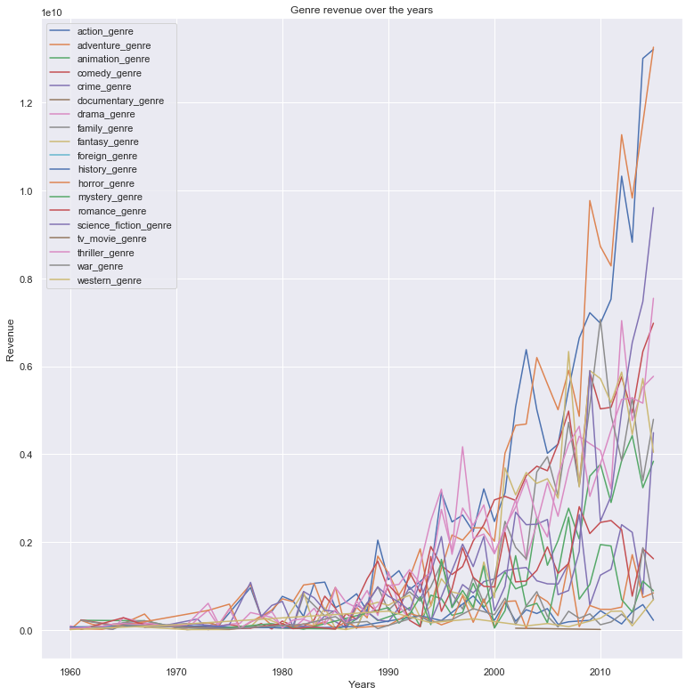

```python
relationYearly("revenue",1000000)
```

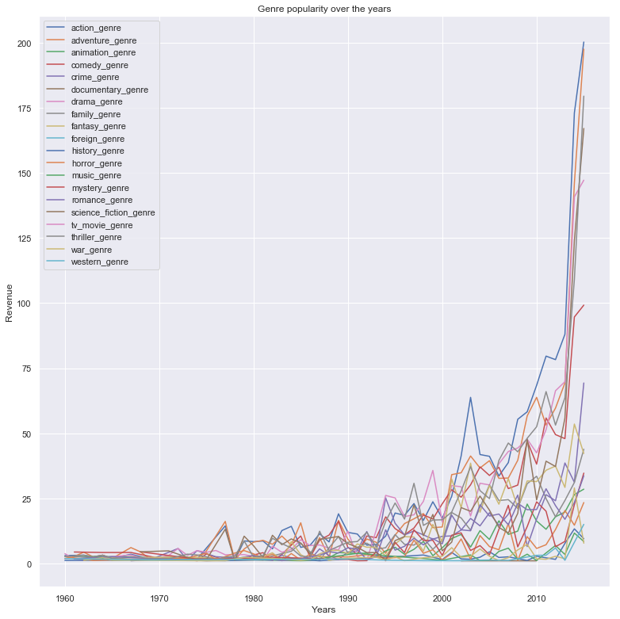

```python
relationYearly("popularity",1)
```

**The following charts are meant to provide an understanding on how much each genre has as share in the respective realm**

This one for example shows documentary to the real lowest in terms of revenue, this is likely because no one watches a documentary in theatre.  
Horror on average also has very little revenue, likely by the fact that it is R rated usually, and that most horror movies low budget generally terrible movies

```python
def drawPieChart(feature):
    revenues_values = []
    genres_labels= []
    fig = plt.figure(figsize=(7,7))
    ax = fig.add_axes([0,0,1,1])
    ax.axis('equal')
    for genre in genres.columns:
        genre_movies = reducedMovies[reducedMovies[genre] == 1]
        mean_rev = genre_movies[feature].mean()
        if mean_rev==0 or math.isnan(mean_rev):
            continue

        genres_labels.append(genre[:genre.find("genre")-1])
        revenues_values.append(mean_rev)

    revenues_values, genres_labels = (list(t) for t in zip(*sorted(zip( revenues_values,genres_labels))))
    explode = np.full(shape=len(revenues_values),fill_value=0.05)
    ax.pie(revenues_values, labels = genres_labels, autopct='%.1f%%', explode = explode)

    ax.set_title('Pie chart')
    plt.title("Best genres by average "+feature)
    plt.show()
```

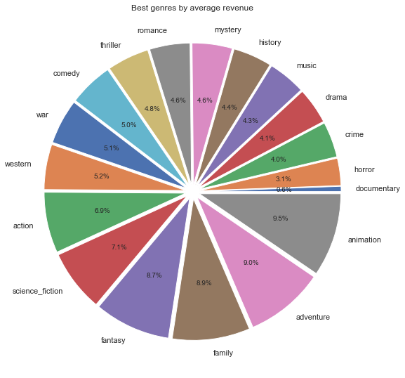

```python
drawPieChart("revenue")
```

This pie chart here shows a decorrelation between it and the previous pie chart, while science fiction is the most popular, it is not by default the most earning.

Most genres are generally out of place an unalligned when comparing their revenue to popularity, generally showing that movies may not earn more, but they can be appreciated for what they are later on.

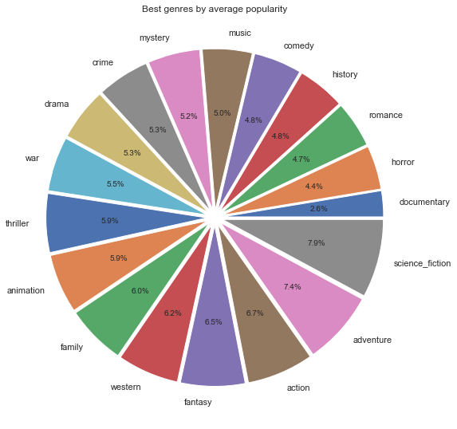

```python
drawPieChart("popularity")
```

The next two charts tell an interesting story, as documentary is still getting low score on vote counts, meaning that not many vote for documentaries.

However in the next chart we find that while most gernes are generally equal in average votes, the highest one by far are documentaries, this indicates that while very little of the documentaries receive any vote at all, those votes are always highly appreciative, and it shows that whoever is watching documentaries is always the type that appreciates any quality provided knowledge

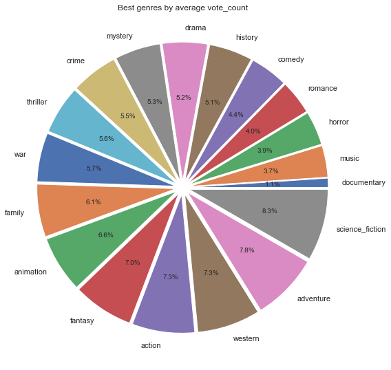

```python
drawPieChart("vote_count")
```

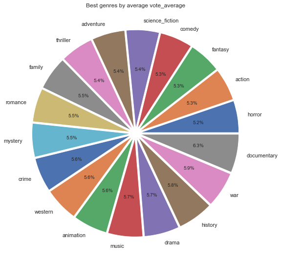

```python
drawPieChart("vote_average")
```

**While the previous charts indicate audience reception. It does not indicate any number, how many of each genre is made, and therefore which ones are more preferred by producers companies. The following chart tries to find the answer to that**

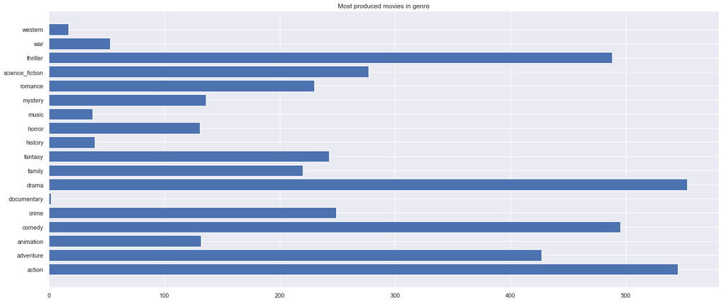

```python
fig = plt.figure(figsize=(17,7))
genres_labels = []
genre_counts = []
ax = fig.add_axes([0,0,1,1])
for genre in genres.columns:
    genre_movies = reducedMovies[reducedMovies[genre] == 1]
    count = genre_movies.vote_average.count()
    if count==0 or math.isnan(count):
        continue

    genres_labels.append(genre[:genre.find("genre")-1])
    genre_counts.append(count)

plt.title("Most produced movies in genre")
ax.barh(genres_labels,genre_counts)
plt.show()
```

## Submitting your Project

> Before you submit your project, you need to create a .html or .pdf version of this notebook in the workspace here. To do that, run the code cell below. If it worked correctly, you should get a return code of 0, and you should see the generated .html file in the workspace directory (click on the orange Jupyter icon in the upper left).

> Alternatively, you can download this report as .html via the **File** > **Download as** submenu, and then manually upload it into the workspace directory by clicking on the orange Jupyter icon in the upper left, then using the Upload button.

> Once you've done this, you can submit your project by clicking on the "Submit Project" button in the lower right here. This will create and submit a zip file with this .ipynb doc and the .html or .pdf version you created. Congratulations!

```python
from subprocess import call
call(['python', '-m', 'nbconvert', 'Investigate_a_Dataset.ipynb'])
```

```
4294967295
```